# How a small wave grows, then fades

The background supplies energy; viscosity helps end the pulse

Published

September 12, 2026

Start with the paper map · Main route, article 7 of 9

The previous article explained how waves can supply useful momentum transport. But where do those waves get their energy? And how can they disappear without leaving a large force when they are switched off?

The paper gives its pulses a carefully arranged life cycle. They begin with a very small seed, grow by drawing energy from the background flow, and later decay strongly enough that they can be cut off with small errors.

The important competition is between **shear**, which can amplify a disturbance, and **viscosity**, which smooths differences in velocity.

## Begin with neighbouring lanes moving at different speeds

Imagine parallel conveyor belts running at different speeds. A disturbance that moves between them encounters different background velocities.

A fluid with neighbouring layers moving at different speeds has shear. That difference provides an energy source: an appropriately arranged disturbance can draw energy from the background.

This does not mean every disturbance grows. Its direction and relationship to the shear matter. Some motions extract energy; others do not.

The paper designs the background and pulse orientations together to obtain the needed amplification.

## See how the wave pattern changes

Draw a stripe across several conveyor belts. As the belts move, they carry different parts of the stripe different distances. The stripe tilts.

A wave pattern in a sheared flow changes in an analogous way. Its orientation evolves, and the spacing of its variations can become smaller in the direction across the shear.

This matters because viscosity acts especially strongly on closely spaced velocity differences.

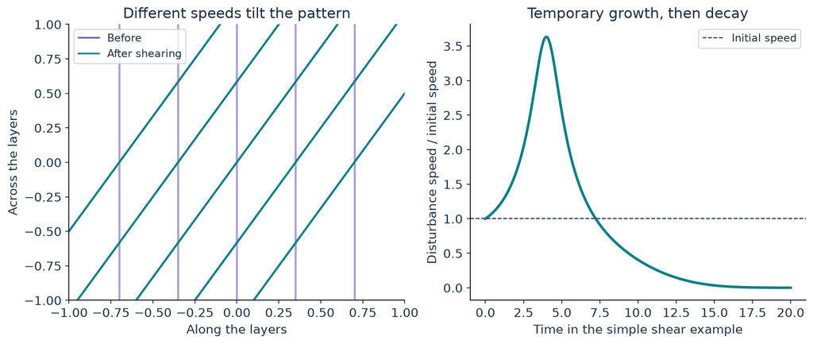

Figure 1: The left panel illustrates stripes being tilted by different background speeds. The right uses the companion’s simple straight-shear example: disturbance speed first grows and then becomes small. This example illustrates transient amplification and decay, not the exact rotating pulse mechanism of the paper.

## Why fine patterns are smoothed faster

Think of temperature differences in a metal bar. Heat has only a short distance to travel between neighbouring hot and cold bands when the bands are tightly spaced.

Velocity differences also diffuse through viscosity. As a useful rule, halving the variation length makes the diffusion time about four times shorter. The distance enters squared.

You can therefore have an early stage when amplification wins and a later stage when increasingly fine variations make damping win.

In the paper, the changing wave orientation also weakens amplification. Both effects help produce growth followed by decay. The pulse cannot be understood by comparing one fixed growth rate with one fixed damping rate for its entire life.

## How the rotating background amplifies a pulse

Here is the source’s physical picture in words. A fluctuation with excess circular velocity can acquire an outward motion. At a larger radius, the surrounding angular velocity is different. Under the chosen shear conditions, the fluctuation’s excess relative to its surroundings can grow.

The effects reinforce one another. Axial shear provides an additional route to amplification, especially where the rotational contribution would be weak.

The paper makes these conditions quantitative and includes viscous damping. Its selected rotating pulse model has an initial amplification stage followed by decay. [Paper, Section 2.2 and Lemma 7.4](https://cdn.openai.com/pdf/32d9f210-8b73-45e0-91bc-82a30aef8a9a/navier-stokes.pdf)

Our conveyor-belt picture explains shearing and energy exchange. It does not reproduce every feature of this rotating instability.

## What the simpler computation shows

The supporting experiment uses a known wave in a straight shear flow. We can calculate its changing orientation and amplitude directly, then compare with a numerical integration.

For its chosen dimensionless parameters, the disturbance speed rises to about **3.6 times** its initial value before decaying. Since energy depends on speed squared, the peak energy is about **13 times** its initial value.

The gain comes from the background shear. It is not energy appearing from nowhere, and it is not evidence that viscosity has become negative.

This straight-shear example demonstrates temporary amplification and eventual viscous decay. The actual paper’s pulse construction uses a different, rotating and axially sheared setting. Keeping that distinction lets the simpler example teach a mechanism without pretending to reproduce the full construction.

## Why the quiet tails matter

Imagine stopping a loudspeaker while its signal is large. An abrupt cutoff introduces a sharp change. Turning it off after the signal has already become tiny is easier to do gently.

The paper similarly applies temporal cutoffs in the pulses’ small tails. The errors introduced by the cutoff must be controlled, including their space-time derivatives.

The seed force also has to remain compatible with the final smooth-force requirement. The source arranges exponentially small seeds and tails; merely drawing a bell-shaped amplitude curve would not establish those estimates.

This connects the pulse’s life cycle directly to the theorem’s force regularity. The pulse needs to be useful in the middle and sufficiently quiet at its ends.

## Where this fits in the bigger picture

**The wave’s energy comes from the background, and its designed decay makes its contribution controllable.** Averaged transport tells us what the pulse does; amplification and damping tell us how it can do that while respecting the viscous dynamics.

Adding pulses still creates new errors and can disturb important weighted totals. Continue with small local repairs that preserve those totals.

The technical article, notebook, and source notes provide the exact straight-shear example and its energy accounting.